# Part I - (Prosper Loan Exploration)

## by (Chijioke Declan Obasi)

## Introduction

> This data set contains 113,937 loans with 81 variables on each loan, including loan amount, borrower rate (or interest rate), current loan status, borrower income, and other important variables which contribute to the whole data set. Data dictionary to understand the variables more form this link: https://docs.google.com/spreadsheets/d/1gDyi_L4UvIrLTEC6Wri5nbaMmkGmLQBk-Yx3z0XDEtI/edit#gid=0

> We are trying to answer these questions
> 1. Are there factors that could possibly affect the loan amount?
> 2. What are the factors that possibly affect a loan’s outcome status?
> 3. What factors or variables affects the borrower’s APR?
> 4. what factors could affect the lender yield as well?

## Preliminary Wrangling

```python
# import all packages and set plots to be embedded inline
import numpy as np
import pandas as pd
import matplotlib.pyplot as plt
import seaborn as sb

%matplotlib inline
```

> Load in your dataset and describe its properties through the questions below. Try and motivate your exploration goals through this section.

```python
raw_data=pd.read_csv('prosperLoanData.csv')
raw_data.head()
```

|  | ListingKey | ListingNumber | ListingCreationDate | CreditGrade | Term | LoanStatus | ClosedDate | BorrowerAPR | BorrowerRate | LenderYield | ... | LP_ServiceFees | LP_CollectionFees | LP_GrossPrincipalLoss | LP_NetPrincipalLoss | LP_NonPrincipalRecoverypayments | PercentFunded | Recommendations | InvestmentFromFriendsCount | InvestmentFromFriendsAmount | Investors |
| --- | --- | --- | --- | --- | --- | --- | --- | --- | --- | --- | --- | --- | --- | --- | --- | --- | --- | --- | --- | --- | --- |
| 0 | 1021339766868145413AB3B | 193129 | 2007-08-26 19:09:29.263000000 | C | 36 | Completed | 2009-08-14 00:00:00 | 0.16516 | 0.1580 | 0.1380 | ... | -133.18 | 0.0 | 0.0 | 0.0 | 0.0 | 1.0 | 0 | 0 | 0.0 | 258 |
| 1 | 10273602499503308B223C1 | 1209647 | 2014-02-27 08:28:07.900000000 | NaN | 36 | Current | NaN | 0.12016 | 0.0920 | 0.0820 | ... | 0.00 | 0.0 | 0.0 | 0.0 | 0.0 | 1.0 | 0 | 0 | 0.0 | 1 |
| 2 | 0EE9337825851032864889A | 81716 | 2007-01-05 15:00:47.090000000 | HR | 36 | Completed | 2009-12-17 00:00:00 | 0.28269 | 0.2750 | 0.2400 | ... | -24.20 | 0.0 | 0.0 | 0.0 | 0.0 | 1.0 | 0 | 0 | 0.0 | 41 |
| 3 | 0EF5356002482715299901A | 658116 | 2012-10-22 11:02:35.010000000 | NaN | 36 | Current | NaN | 0.12528 | 0.0974 | 0.0874 | ... | -108.01 | 0.0 | 0.0 | 0.0 | 0.0 | 1.0 | 0 | 0 | 0.0 | 158 |
| 4 | 0F023589499656230C5E3E2 | 909464 | 2013-09-14 18:38:39.097000000 | NaN | 36 | Current | NaN | 0.24614 | 0.2085 | 0.1985 | ... | -60.27 | 0.0 | 0.0 | 0.0 | 0.0 | 1.0 | 0 | 0 | 0.0 | 20 |

5 rows × 81 columns

```python
raw_data.columns
```

```
Index(['ListingKey', 'ListingNumber', 'ListingCreationDate', 'CreditGrade',
       'Term', 'LoanStatus', 'ClosedDate', 'BorrowerAPR', 'BorrowerRate',
       'LenderYield', 'EstimatedEffectiveYield', 'EstimatedLoss',
       'EstimatedReturn', 'ProsperRating (numeric)', 'ProsperRating (Alpha)',
       'ProsperScore', 'ListingCategory (numeric)', 'BorrowerState',
       'Occupation', 'EmploymentStatus', 'EmploymentStatusDuration',
       'IsBorrowerHomeowner', 'CurrentlyInGroup', 'GroupKey',
       'DateCreditPulled', 'CreditScoreRangeLower', 'CreditScoreRangeUpper',
       'FirstRecordedCreditLine', 'CurrentCreditLines', 'OpenCreditLines',
       'TotalCreditLinespast7years', 'OpenRevolvingAccounts',
       'OpenRevolvingMonthlyPayment', 'InquiriesLast6Months', 'TotalInquiries',
       'CurrentDelinquencies', 'AmountDelinquent', 'DelinquenciesLast7Years',
       'PublicRecordsLast10Years', 'PublicRecordsLast12Months',
       'RevolvingCreditBalance', 'BankcardUtilization',
       'AvailableBankcardCredit', 'TotalTrades',
       'TradesNeverDelinquent (percentage)', 'TradesOpenedLast6Months',
       'DebtToIncomeRatio', 'IncomeRange', 'IncomeVerifiable',
       'StatedMonthlyIncome', 'LoanKey', 'TotalProsperLoans',
       'TotalProsperPaymentsBilled', 'OnTimeProsperPayments',
       'ProsperPaymentsLessThanOneMonthLate',
       'ProsperPaymentsOneMonthPlusLate', 'ProsperPrincipalBorrowed',
       'ProsperPrincipalOutstanding', 'ScorexChangeAtTimeOfListing',
       'LoanCurrentDaysDelinquent', 'LoanFirstDefaultedCycleNumber',
       'LoanMonthsSinceOrigination', 'LoanNumber', 'LoanOriginalAmount',
       'LoanOriginationDate', 'LoanOriginationQuarter', 'MemberKey',
       'MonthlyLoanPayment', 'LP_CustomerPayments',
       'LP_CustomerPrincipalPayments', 'LP_InterestandFees', 'LP_ServiceFees',
       'LP_CollectionFees', 'LP_GrossPrincipalLoss', 'LP_NetPrincipalLoss',
       'LP_NonPrincipalRecoverypayments', 'PercentFunded', 'Recommendations',
       'InvestmentFromFriendsCount', 'InvestmentFromFriendsAmount',
       'Investors'],
      dtype='object')
```

```python
raw_data.shape
```

```
(113937, 81)
```

```python
# Taking out specific columns and data that i will be working with

loan_data = raw_data.loc[:,('ListingCreationDate', 'Term','LoanStatus', 'ClosedDate','BorrowerAPR','BorrowerRate',
    'LenderYield','ProsperRating (Alpha)','ProsperScore','ListingCategory (numeric)','BorrowerState','Occupation','EmploymentStatus','IncomeRange','StatedMonthlyIncome',
    'LoanMonthsSinceOrigination','LoanOriginalAmount','LoanOriginationDate','LoanOriginationQuarter',
    'MonthlyLoanPayment') ]
```

```python
loan_data.info()
```

```
<class 'pandas.core.frame.DataFrame'>
RangeIndex: 113937 entries, 0 to 113936
Data columns (total 20 columns):
 #   Column                      Non-Null Count   Dtype
---  ------                      --------------   -----
 0   ListingCreationDate         113937 non-null  object
 1   Term                        113937 non-null  int64
 2   LoanStatus                  113937 non-null  object
 3   ClosedDate                  55089 non-null   object
 4   BorrowerAPR                 113912 non-null  float64
 5   BorrowerRate                113937 non-null  float64
 6   LenderYield                 113937 non-null  float64
 7   ProsperRating (Alpha)       84853 non-null   object
 8   ProsperScore                84853 non-null   float64
 9   ListingCategory (numeric)   113937 non-null  int64
 10  BorrowerState               108422 non-null  object
 11  Occupation                  110349 non-null  object
 12  EmploymentStatus            111682 non-null  object
 13  IncomeRange                 113937 non-null  object
 14  StatedMonthlyIncome         113937 non-null  float64
 15  LoanMonthsSinceOrigination  113937 non-null  int64
 16  LoanOriginalAmount          113937 non-null  int64
 17  LoanOriginationDate         113937 non-null  object
 18  LoanOriginationQuarter      113937 non-null  object
 19  MonthlyLoanPayment          113937 non-null  float64
dtypes: float64(6), int64(4), object(10)
memory usage: 17.4+ MB
```

```python
loan_data.head(10)
```

|  | ListingCreationDate | Term | LoanStatus | ClosedDate | BorrowerAPR | BorrowerRate | LenderYield | ProsperRating (Alpha) | ProsperScore | ListingCategory (numeric) | BorrowerState | Occupation | EmploymentStatus | IncomeRange | StatedMonthlyIncome | LoanMonthsSinceOrigination | LoanOriginalAmount | LoanOriginationDate | LoanOriginationQuarter | MonthlyLoanPayment |
| --- | --- | --- | --- | --- | --- | --- | --- | --- | --- | --- | --- | --- | --- | --- | --- | --- | --- | --- | --- | --- |
| 0 | 2007-08-26 19:09:29.263000000 | 36 | Completed | 2009-08-14 00:00:00 | 0.16516 | 0.1580 | 0.1380 | NaN | NaN | 0 | CO | Other | Self-employed | $25,000-49,999 | 3083.333333 | 78 | 9425 | 2007-09-12 00:00:00 | Q3 2007 | 330.43 |
| 1 | 2014-02-27 08:28:07.900000000 | 36 | Current | NaN | 0.12016 | 0.0920 | 0.0820 | A | 7.0 | 2 | CO | Professional | Employed | $50,000-74,999 | 6125.000000 | 0 | 10000 | 2014-03-03 00:00:00 | Q1 2014 | 318.93 |
| 2 | 2007-01-05 15:00:47.090000000 | 36 | Completed | 2009-12-17 00:00:00 | 0.28269 | 0.2750 | 0.2400 | NaN | NaN | 0 | GA | Other | Not available | Not displayed | 2083.333333 | 86 | 3001 | 2007-01-17 00:00:00 | Q1 2007 | 123.32 |
| 3 | 2012-10-22 11:02:35.010000000 | 36 | Current | NaN | 0.12528 | 0.0974 | 0.0874 | A | 9.0 | 16 | GA | Skilled Labor | Employed | $25,000-49,999 | 2875.000000 | 16 | 10000 | 2012-11-01 00:00:00 | Q4 2012 | 321.45 |
| 4 | 2013-09-14 18:38:39.097000000 | 36 | Current | NaN | 0.24614 | 0.2085 | 0.1985 | D | 4.0 | 2 | MN | Executive | Employed | $100,000+ | 9583.333333 | 6 | 15000 | 2013-09-20 00:00:00 | Q3 2013 | 563.97 |
| 5 | 2013-12-14 08:26:37.093000000 | 60 | Current | NaN | 0.15425 | 0.1314 | 0.1214 | B | 10.0 | 1 | NM | Professional | Employed | $100,000+ | 8333.333333 | 3 | 15000 | 2013-12-24 00:00:00 | Q4 2013 | 342.37 |
| 6 | 2013-04-12 09:52:56.147000000 | 36 | Current | NaN | 0.31032 | 0.2712 | 0.2612 | E | 2.0 | 1 | KS | Sales - Retail | Employed | $25,000-49,999 | 2083.333333 | 11 | 3000 | 2013-04-18 00:00:00 | Q2 2013 | 122.67 |
| 7 | 2013-05-05 06:49:27.493000000 | 36 | Current | NaN | 0.23939 | 0.2019 | 0.1919 | C | 4.0 | 2 | CA | Laborer | Employed | $25,000-49,999 | 3355.750000 | 10 | 10000 | 2013-05-13 00:00:00 | Q2 2013 | 372.60 |
| 8 | 2013-12-02 10:43:39.117000000 | 36 | Current | NaN | 0.07620 | 0.0629 | 0.0529 | AA | 9.0 | 7 | IL | Food Service | Employed | $25,000-49,999 | 3333.333333 | 3 | 10000 | 2013-12-12 00:00:00 | Q4 2013 | 305.54 |
| 9 | 2013-12-02 10:43:39.117000000 | 36 | Current | NaN | 0.07620 | 0.0629 | 0.0529 | AA | 11.0 | 7 | IL | Food Service | Employed | $25,000-49,999 | 3333.333333 | 3 | 10000 | 2013-12-12 00:00:00 | Q4 2013 | 305.54 |

```python
loan_data.shape
```

```
(113937, 20)
```

```python
loan_data.isnull().sum()
```

```
ListingCreationDate               0
Term                              0
LoanStatus                        0
ClosedDate                    58848
BorrowerAPR                      25
BorrowerRate                      0
LenderYield                       0
ProsperRating (Alpha)         29084
ProsperScore                  29084
ListingCategory (numeric)         0
BorrowerState                  5515
Occupation                     3588
EmploymentStatus               2255
IncomeRange                       0
StatedMonthlyIncome               0
LoanMonthsSinceOrigination        0
LoanOriginalAmount                0
LoanOriginationDate               0
LoanOriginationQuarter            0
MonthlyLoanPayment                0
dtype: int64
```

```python
#Make a copy of the data frame
loan_data_clean = loan_data.copy()

#Adjust Datetime columns to appropriate dtypes
loan_data_clean.ListingCreationDate = pd.to_datetime(loan_data_clean.ListingCreationDate)
loan_data_clean.ClosedDate = pd.to_datetime(loan_data_clean.ClosedDate)
loan_data_clean.LoanOriginationDate = pd.to_datetime(loan_data_clean.LoanOriginationDate)
```

```python
#convert ProsperRating (Alpha) and  IncomeRange to ordinal categorical variables
ordinal_var = {'ProsperRating (Alpha)': ['N/A','HR','E','D','C', 'B', 'A', 'AA'],\
                    'IncomeRange':['$0','$1-24,999','$25,000-49,999','$50,000-74,999','$75,000-99,999','$100,000+']}
for var in ordinal_var:
    ordered_var = pd.api.types.CategoricalDtype(ordered = True,categories = ordinal_var[var])
    loan_data_clean[var] = loan_data_clean[var].astype(ordered_var)

#convert oblect datatype for all other categorical columns
loan_data_clean['Occupation']= loan_data_clean['Occupation'].astype('category')
loan_data_clean['BorrowerState'] = loan_data_clean['BorrowerState'].astype('category')
loan_data_clean['LoanStatus'] = loan_data_clean['LoanStatus'].astype('category')
loan_data_clean['ListingCategory (numeric)'] = loan_data_clean['ListingCategory (numeric)'].astype('category')
loan_data_clean['EmploymentStatus'] = loan_data_clean['EmploymentStatus'].astype('category')
```

```python
loan_data_clean.info()
```

```
<class 'pandas.core.frame.DataFrame'>
RangeIndex: 113937 entries, 0 to 113936
Data columns (total 20 columns):
 #   Column                      Non-Null Count   Dtype
---  ------                      --------------   -----
 0   ListingCreationDate         113937 non-null  datetime64[ns]
 1   Term                        113937 non-null  int64
 2   LoanStatus                  113937 non-null  category
 3   ClosedDate                  55089 non-null   datetime64[ns]
 4   BorrowerAPR                 113912 non-null  float64
 5   BorrowerRate                113937 non-null  float64
 6   LenderYield                 113937 non-null  float64
 7   ProsperRating (Alpha)       84853 non-null   category
 8   ProsperScore                84853 non-null   float64
 9   ListingCategory (numeric)   113937 non-null  category
 10  BorrowerState               108422 non-null  category
 11  Occupation                  110349 non-null  category
 12  EmploymentStatus            111682 non-null  category
 13  IncomeRange                 105390 non-null  category
 14  StatedMonthlyIncome         113937 non-null  float64
 15  LoanMonthsSinceOrigination  113937 non-null  int64
 16  LoanOriginalAmount          113937 non-null  int64
 17  LoanOriginationDate         113937 non-null  datetime64[ns]
 18  LoanOriginationQuarter      113937 non-null  object
 19  MonthlyLoanPayment          113937 non-null  float64
dtypes: category(7), datetime64[ns](3), float64(6), int64(3), object(1)
memory usage: 12.1+ MB
```

```python
loan_data_clean['IncomeRange'].value_counts()
```

```
$25,000-49,999    32192
$50,000-74,999    31050
$100,000+         17337
$75,000-99,999    16916
$1-24,999          7274
$0                  621
Name: IncomeRange, dtype: int64
```

From the above data presentation, most of the incomerange of those borowerring fall from $25,000 down to 74,999.

```python
loan_data_clean.shape
```

```
(113937, 20)
```

```python
loan_data_clean.describe()
```

|  | Term | BorrowerAPR | BorrowerRate | LenderYield | ProsperScore | StatedMonthlyIncome | LoanMonthsSinceOrigination | LoanOriginalAmount | MonthlyLoanPayment |
| --- | --- | --- | --- | --- | --- | --- | --- | --- | --- |
| count | 113937.000000 | 113912.000000 | 113937.000000 | 113937.000000 | 84853.000000 | 1.139370e+05 | 113937.000000 | 113937.00000 | 113937.000000 |
| mean | 40.830248 | 0.218828 | 0.192764 | 0.182701 | 5.950067 | 5.608026e+03 | 31.896882 | 8337.01385 | 272.475783 |
| std | 10.436212 | 0.080364 | 0.074818 | 0.074516 | 2.376501 | 7.478497e+03 | 29.974184 | 6245.80058 | 192.697812 |
| min | 12.000000 | 0.006530 | 0.000000 | -0.010000 | 1.000000 | 0.000000e+00 | 0.000000 | 1000.00000 | 0.000000 |
| 25% | 36.000000 | 0.156290 | 0.134000 | 0.124200 | 4.000000 | 3.200333e+03 | 6.000000 | 4000.00000 | 131.620000 |
| 50% | 36.000000 | 0.209760 | 0.184000 | 0.173000 | 6.000000 | 4.666667e+03 | 21.000000 | 6500.00000 | 217.740000 |
| 75% | 36.000000 | 0.283810 | 0.250000 | 0.240000 | 8.000000 | 6.825000e+03 | 65.000000 | 12000.00000 | 371.580000 |
| max | 60.000000 | 0.512290 | 0.497500 | 0.492500 | 11.000000 | 1.750003e+06 | 100.000000 | 35000.00000 | 2251.510000 |

```python
# checking for duplicated values
loan_data_clean.duplicated().sum()
```

```
0
```

### What is the structure of your dataset?

> The structure of the dataset just after a prelimenary data wrangling was 113937 rows and 20 columns, with a reduction in columns

### What is/are the main feature(s) of interest in your dataset?

> The main feature(s) i will be focusing on Borrower Rate, Borrower APR, Prosper Score, Original Loan Amount, EmplomentStatus.

### What features in the dataset do you think will help support your investigation into your feature(s) of interest?

##### Some Other features which i feel will affect the mentioned important features are:

> Some of other features i feel will support my investigation are:
> 1. Lender Yield
> 2. LoanStatus
> 3. BorrowerState

## Univariate Exploration

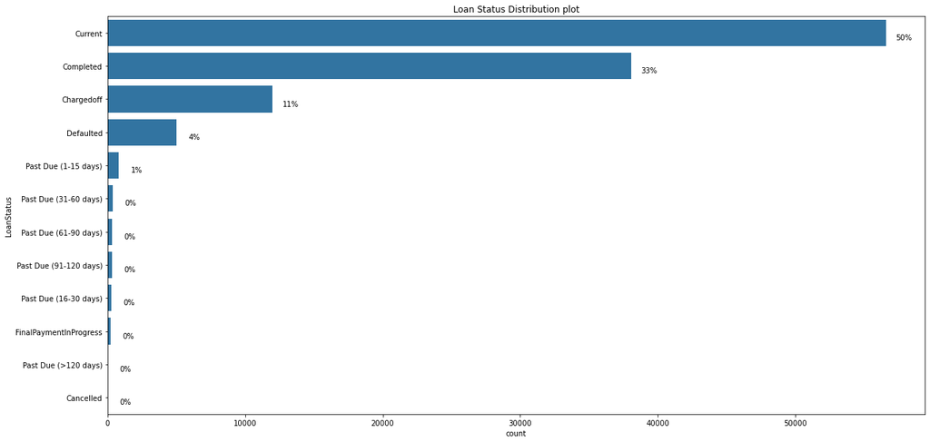

```python
# Loan Status Distribution
plt.figure(figsize=[20, 10])
status_order = loan_data_clean['LoanStatus'].value_counts().index
sb.countplot(data=loan_data_clean,y='LoanStatus',color=base_color,order=status_order);
plt.title('Loan Status Distribution plot')

# logic to print the text (proportional) on the bars of the horizontal plot
n_points = loan_data_clean.shape[0]
cat_counts = loan_data_clean['LoanStatus'].value_counts()
locs, labels = plt.yticks()
for loc, label in zip(locs, labels):
    count = cat_counts[label.get_text()]
    pct_string = '{:0.0f}%'.format(100*count/n_points)
    plt.text(count+1300, loc+0.2,  pct_string, ha = 'center', color = 'black');
```

> Most of the loans are Current

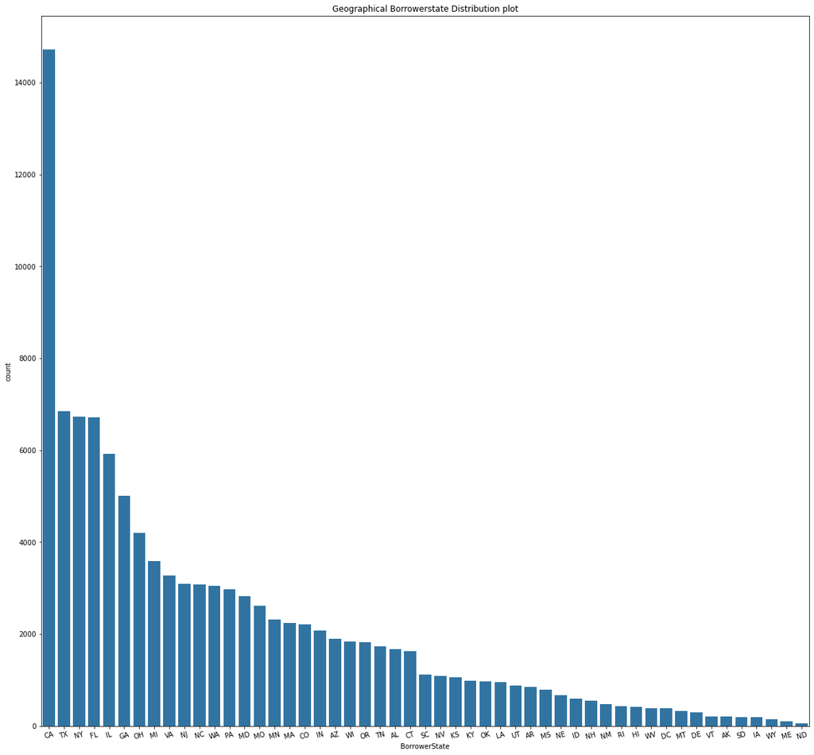

```python
plt.figure(figsize=[20,19])
borrow_ordered = loan_data['BorrowerState'].value_counts().index
sb.countplot(data= loan_data_clean, x='BorrowerState', color=base_color, order=borrow_ordered);
plt.title('Geographical Borrowerstate Distribution plot')
plt.xticks(rotation=15)
plt.show();
```

> California top the list , followed by Texas, New York, and florida states who have a closed range with each other of the numbers of loans originated in that period of time

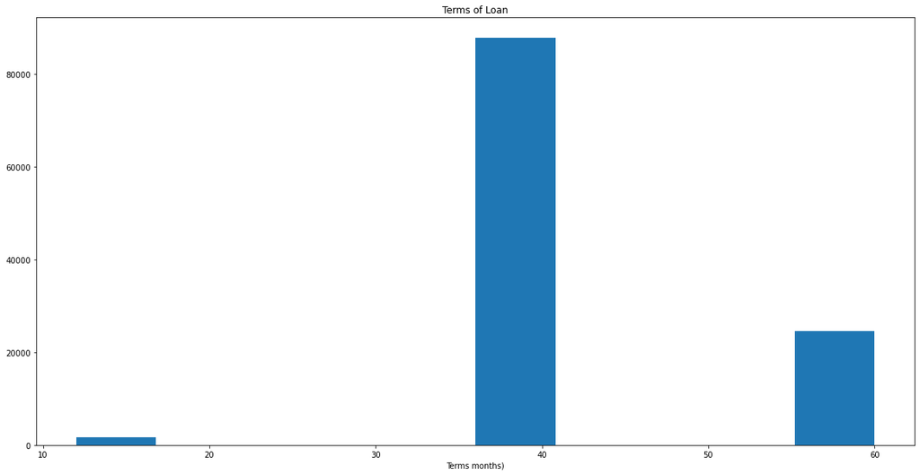

```python
plt.figure(figsize=[20,10])
base_color= sb.color_palette()[0]
plt.hist(data= loan_data_clean, x= 'Term', color=base_color)
plt.xlabel('Terms months)')
plt.title('Terms of Loan')
```

it is very obivous that most of the values fall between 35 to 40 months duration for payment period.

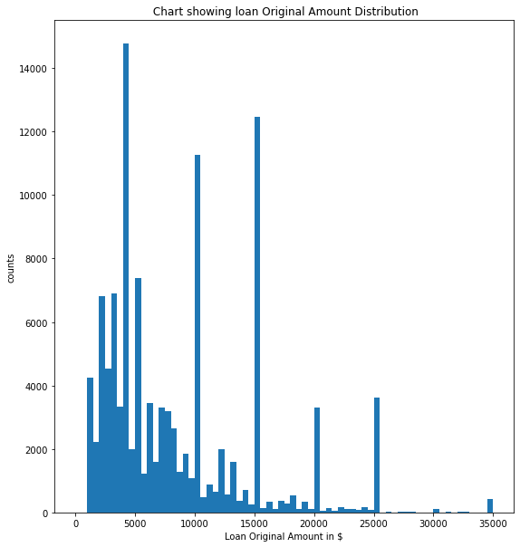

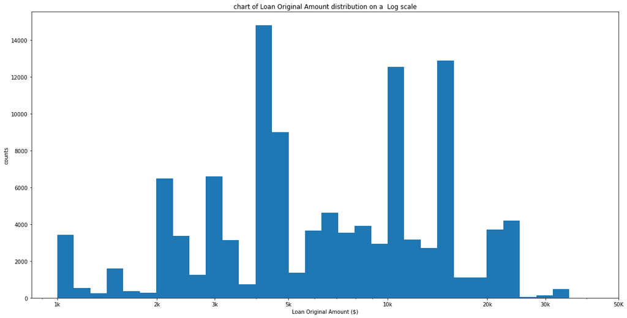

```python
# Loan Original Amount Distribution
bins = np.arange(0, loan_data_clean['LoanOriginalAmount'].max()+500, 500)


plt.figure(figsize=[20, 10])
plt.subplot(1,2,1), (1,2,2)
plt.hist(data = loan_data_clean, x = 'LoanOriginalAmount', bins = bins)
plt.xlabel('Loan Original Amount in $')
plt.ylabel('counts')
plt.title(' Chart showing loan Original Amount Distribution')
plt.show();

# Putting it in a log-scale
plt.figure(figsize=[20, 10])
log_binsize = 0.05
bins_size = 10 ** np.arange(3, np.log10(loan_data_clean['LoanOriginalAmount'].max())+log_binsize, log_binsize)
plt.hist(data = loan_data_clean, x = 'LoanOriginalAmount', bins = bins_size)
plt.xscale('log')
plt.xticks([1e3, 2e3, 3e3, 5e3, 1e4, 2e4, 3e4, 5e4], ['1k', '2k','3k', '5k', '10k', '20k', '30k', '50K'])
plt.xlabel('Loan Original Amount ($)')
plt.ylabel('counts')
plt.title('chart of Loan Original Amount distribution on a  Log scale')
plt.show();
```

> 1. From the first distribution plot, it is clear that is skewed to the right. So, a plot in a log scale would be better to get a clearer visualization and understanding.
> 2. The second plot which is in a log scale, actually gives A better representation and disstribution of the variable with most of the data falling between 3k and 5k. Also notice that we have more data between the 10k and 20k.

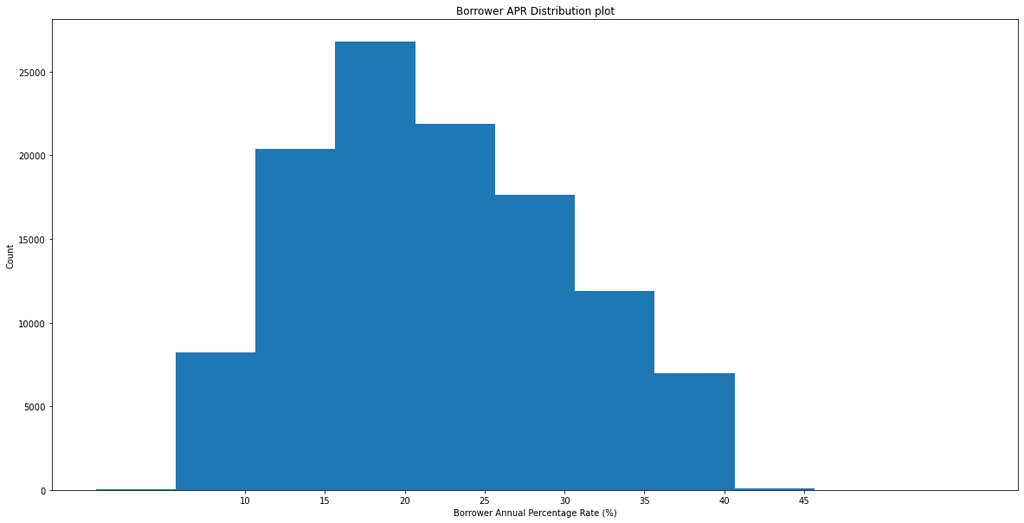

```python
#Distribution of Borrower APR in percentage
BorrowerAPRP_percent = loan_data_clean['BorrowerAPR']*100
#creating a binsize
bins = np.arange(loan_data_clean['BorrowerAPR'].min()*100, loan_data_clean['BorrowerAPR'].max()*100+5, 5)

plt.figure(figsize=[20, 10])
plt.hist(x = BorrowerAPRP_percent, bins = bins)
plt.xlabel('Borrower Annual Percentage Rate (%)')
plt.ylabel('Count')
plt.xticks([10, 15, 20, 25, 30, 35, 40, 45], ['10', '15', '20', '25', '30', '35', '40', '45'])
plt.title('Borrower APR Distribution plot')
plt.show()
```

> We see that the Borrower APR is normally distrubuted with the peak between 15 and 20 percent. in addition, a further reduction in the bin size could help for better insight which would lead us to the next plot.

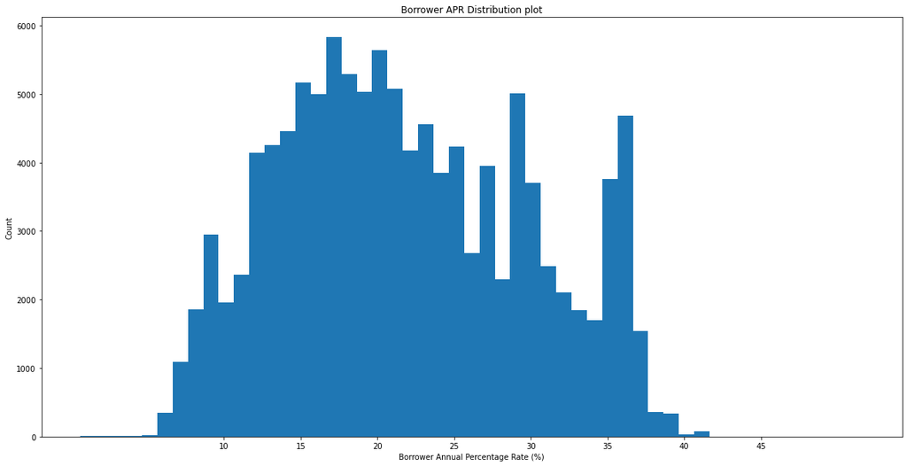

```python
BorrowerAPRP_percent = loan_data_clean['BorrowerAPR']*100
bins = np.arange(loan_data_clean['BorrowerAPR'].min()*100, loan_data_clean['BorrowerAPR'].max()*100+1,1)

plt.figure(figsize=[20, 10])
plt.hist(x = BorrowerAPRP_percent, bins = bins)
plt.xlabel('Borrower Annual Percentage Rate (%)')
plt.ylabel('Count')
plt.xticks([10, 15, 20, 25, 30, 35, 40, 45], ['10', '15', '20', '25', '30', '35', '40', '45'])
plt.title('Borrower APR Distribution plot')
plt.show()
```

> Now We see that after reducing the size of the bin,the Borrower APR is still normally distrubuted with the peak same between 15 and 20 percent, but a spike in height around 30 percent and just after 35 percent. This gives a possible insight for invgestigate these points.

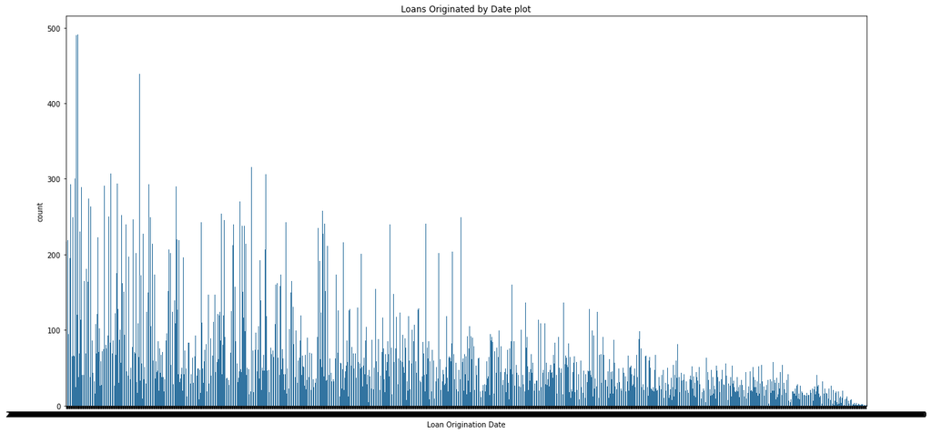

```python
# Loan Origination by Date
plt.figure(figsize=[20, 10])
sb.countplot(data=loan_data_clean,x=loan_data_clean['LoanOriginationDate'],color=base_color)
plt.title('Loans Originated by Date plot')
plt.xlabel('Loan Origination Date');
```

ploting the loanoriginationdate does not give a clear visualization, scaling it up to year might be better.

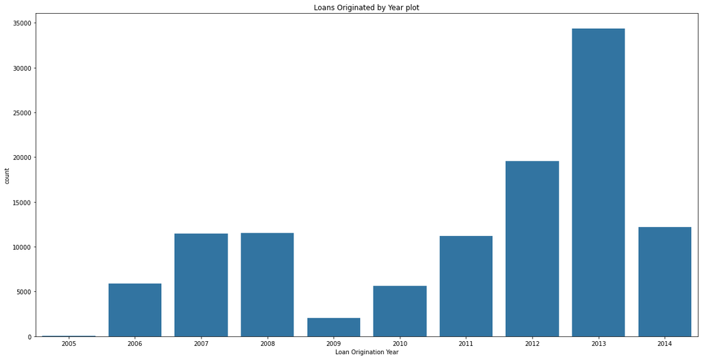

```python
#loan originated by year
plt.figure(figsize=[20, 10])
sb.countplot(data=loan_data_clean,x=loan_data_clean['LoanOriginationDate'].dt.year,color=base_color)
plt.title('Loans Originated by Year plot')
plt.xlabel('Loan Origination Year');
```

> From the chart, there was a significant drop in 2009, which was as a result of the economic recession that stroked in 2008. But it seems after 2009, there was gradual increase in the amount of loan collected up to 2013 and there comes a drop in 2014.

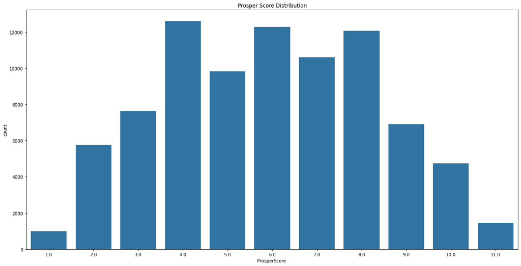

```python
plt.figure(figsize=[20,10])
base_color= sb.color_palette()[0]
sb.countplot(data=loan_data_clean, x='ProsperScore', color=base_color)
plt.xlabel('ProsperScore ')
plt.ylabel('count')
plt.title('Prosper Score Distribution')
```

ProsperScores have a normal distribution kind of plot with scores 4, 6 and 8 been the most common.

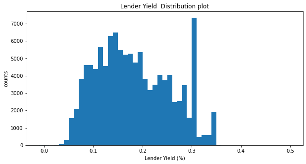

```python
# LenderYield Distribution
plt.figure(figsize=[20,10])
binsize = 0.01
bins = np.arange(loan_data_clean['LenderYield'].min(),loan_data_clean['LenderYield'].max()+binsize, binsize)

plt.figure(figsize=[10, 5])
plt.hist(data = loan_data_clean, x = 'LenderYield', bins = bins)
plt.xlabel('Lender Yield (%)')
plt.ylabel('counts')
plt.title('Lender Yield  Distribution plot')
plt.show();
```

> The chart Lender Yield present a nomarlly distributed plot with most of the values between 0.1 and 0.2, but have an outragous hike in count on 0.3 percent lender yield.

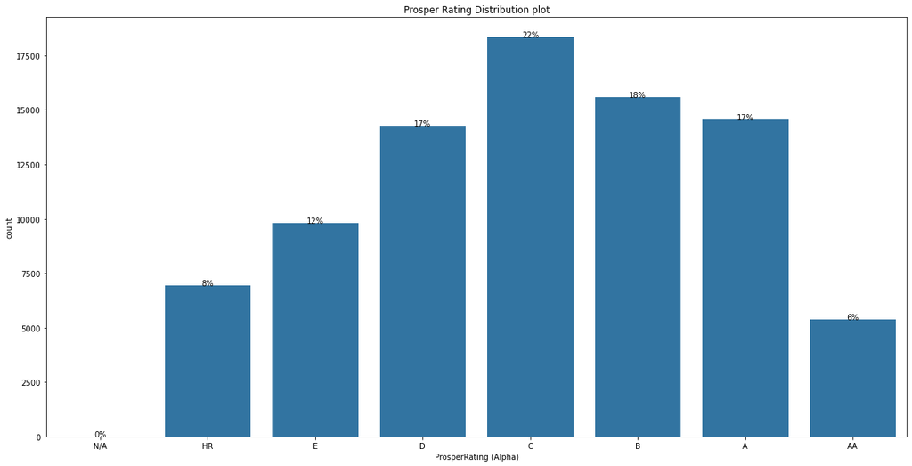

```python
plt.figure(figsize=[20,10])
sb.countplot(data= loan_data_clean, x= 'ProsperRating (Alpha)'
             , color= base_color);
plt.title('Prosper Rating Distribution plot')

#logic to print the text (proportional) inside the bars of the vertical plot
n_values = loan_data_clean[loan_data_clean['ProsperRating (Alpha)'].isna() == False].shape[0]
cat_counts = loan_data_clean['ProsperRating (Alpha)'].value_counts()
locs, labels = plt.xticks()
for loc, label in zip(locs, labels):
    count = cat_counts[label.get_text()]
    pct_string = '{:0.0f}%'.format(100*count/n_values)
    plt.text(loc,  count+5, pct_string, ha = 'center', color = 'black');
```

Most the borrowers have ProsperRating of 'C' having a percentage of 22%.

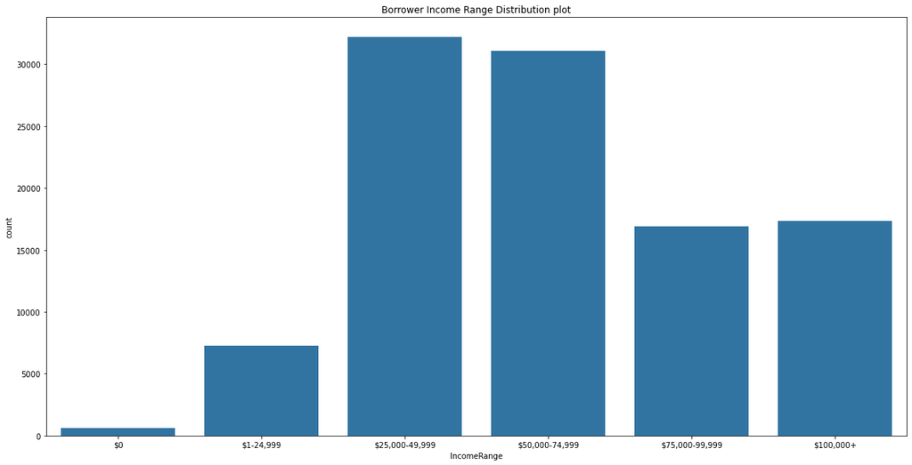

```python
#Income range distribution plot
plt.figure(figsize=[20, 10])
sb.countplot(data = loan_data_clean, x='IncomeRange', color= base_color);
plt.title('Borrower Income Range Distribution plot')
plt.show;
```

> It is clear that people with yearly income range of $25,000-49,999 are the most taking loans

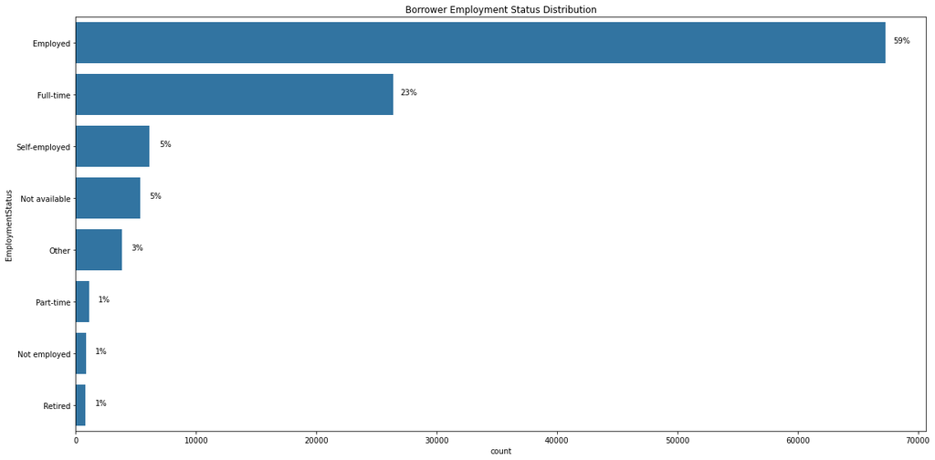

```python
#Borrower Employment Status Distrobution
cat_order = loan_data_clean.EmploymentStatus.value_counts().index
plt.figure(figsize=[20, 10])
sb.countplot(data=loan_data_clean,y='EmploymentStatus',color=base_color, order=cat_order);
plt.title('Borrower Employment Status Distribution')

#
n_points = loan_data_clean.shape[0]
cat_counts = loan_data_clean['EmploymentStatus'].value_counts()
locs, labels = plt.yticks()
for loc, label in zip(locs, labels):
    count = cat_counts[label.get_text()]
    pct_string = '{:0.0f}%'.format(100*count/n_points)
    plt.text(count+1300, loc,  pct_string, ha = 'center', color = 'black');
```

> From the chart, we can see that most of the borrowers are employed with a percentage value of 59,

```python
loan_data_clean.head()
```

[output not shown]

### Discuss the distribution(s) of your variable(s) of interest. Were there any unusual points? Did you need to perform any transformations?

> Loan original amount distribution is right skewed and i performed log transformation on it to interpret the visulization. Also the term of loan saw a period of 36 months **(3 years)**.

> year 2013 had the highest creation. california (CA) state had the biggest number of loans.and most of the borrowers were employed and the loan status was current /active.

### Of the features you investigated, were there any unusual distributions? Did you perform any operations on the data to tidy, adjust, or change the form of the data? If so, why did you do this?

> Some features had long-tailed, skewed distributions, these were checked on a log-scale which revealed the hidden distribution in some areas and gave better understanding why the data was display like that. Also, the loanoriginationdate gave a noisy chart, but scaling it up to year produced a better visual.

## Bivariate Exploration

### Lets look out the correlation matrix to get a quick of the relationship between some specifc variables

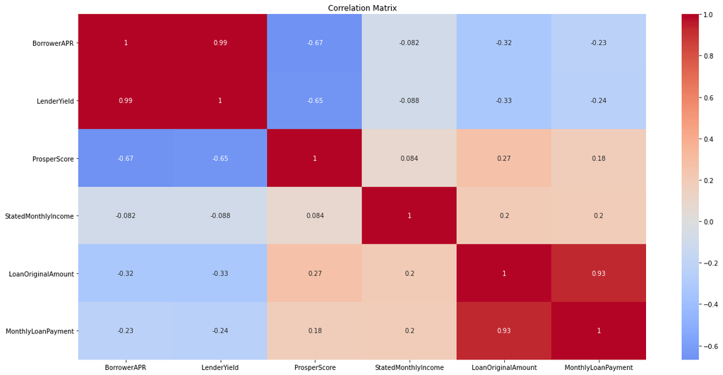

```python
plt.figure(figsize=[20, 10])
sb.heatmap(loan_data_clean[['BorrowerAPR', 'LenderYield', 'ProsperScore','StatedMonthlyIncome','LoanOriginalAmount','MonthlyLoanPayment']].corr(), annot = True,
           cmap = 'coolwarm', center = 0)
plt.title('Correlation Matrix')
plt.show();
```

##### >Based on the correlation matrix above, there are some relations of interest:

> 1. ProsperScore and BorrowerAPR: A Negative relationship was indicated, lower score means higher risks and hence higher interest rates.
> 2. BorrowerAPR and LenderYield: A Strong positive relationship was shown meaning, the higher the rate the higher the lender earns.
> 3. LoanOriginalAmount and MonthlyLoanPayment: A Strong positive relationship, which sounds very relatable, that the bigger the loan the bigger the monthly payments
> 4. LenderYield and ProsperScore: A negative relationship, this is also logic, the higher the score, lower interest rate and hence lower lender yield.
> 5. LoanOriginalAmount and BorrowerAPR: A negative relationship, we may expect that the bigger the loan amount the less the interest rate.

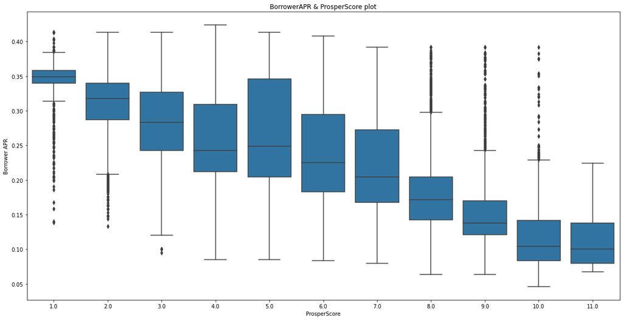

```python
plt.figure(figsize=[20, 10])
sb.boxplot(data=loan_data_clean,y='BorrowerAPR',x='ProsperScore',color=base_color);
plt.title('BorrowerAPR & ProsperScore plot');
plt.ylabel('Borrower APR');
plt.xlabel('ProsperScore')
plt.show();
```

> This shows a negative relationship or a declination across the plot, a higher ProsperScore of values 10,11 have way lower interest rate compared to prosperscore with low value which have high interest rate.

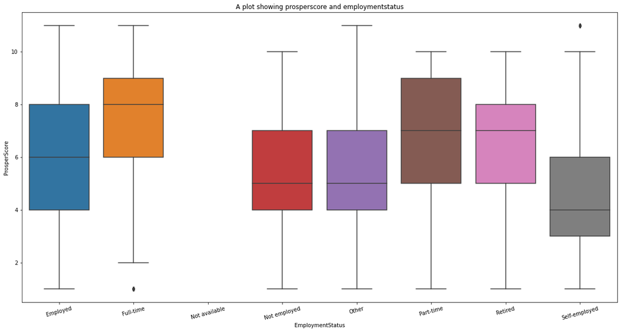

```python
plt.figure(figsize=[20,10])
sb.boxplot(x="EmploymentStatus", y='ProsperScore', data=loan_data_clean )
plt.title('A plot showing prosperscore and employmentstatus')
plt.xticks(rotation=15)
plt.show();
```

More full time workers have higher prosperscore than employed workers.

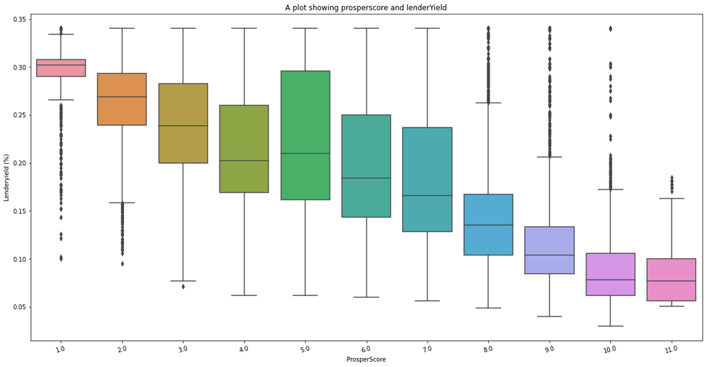

```python
plt.figure(figsize=[20,10])
sb.boxplot(y='LenderYield', x='ProsperScore', data=loan_data_clean )
plt.ylabel('Lenderyield (%)')
plt.title('A plot showing prosperscore and lenderYield')
plt.xticks(rotation=15)
plt.show();
```

Looking through the plot, there is a decrease from left to right which implies an inverse reeationship between the two variables. A high lender yield have a low prosperscore.

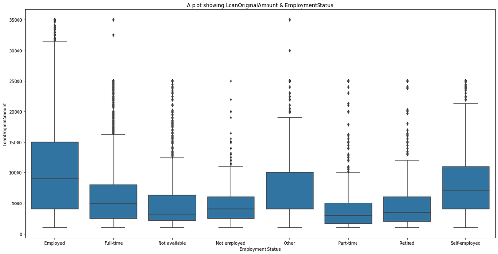

```python
plt.figure(figsize=[20, 10])
sb.boxplot(data=loan_data_clean,y='LoanOriginalAmount',x='EmploymentStatus',color=base_color);
plt.ylabel('LoanOriginalAmount');
plt.xlabel('Employment Status');
plt.title('A plot showing LoanOriginalAmount & EmploymentStatus')
plt.show();
```

> Most Employed people get larger loan amounts compared to all other categories

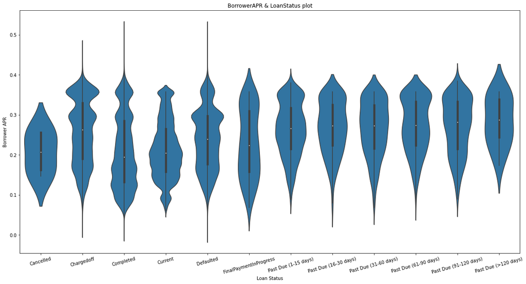

```python
# Borrower APR vs Status of Loan
plt.figure(figsize=[20, 10])
sb.violinplot(data= loan_data_clean,y='BorrowerAPR',x='LoanStatus',color=base_color);
plt.title('BorrowerAPR & LoanStatus plot');
plt.ylabel('Borrower APR');
plt.xlabel('Loan Status');
plt.xticks(rotation=15)
plt.show();
```

> On BorrowerAPR vs LoanStatus graph we notice that Current and completed loans have lower rate than the past-due loans and have lower mean.

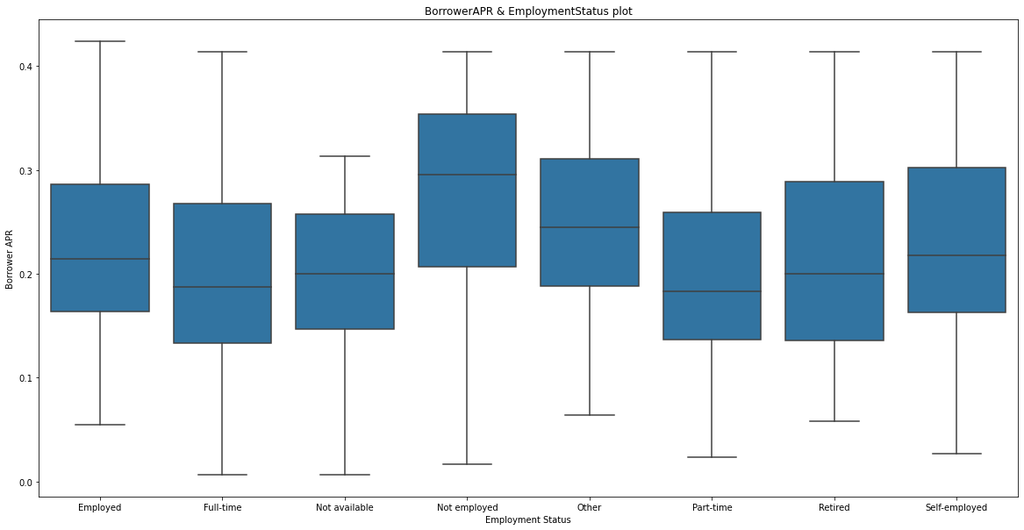

```python
# PLOTTING Borrower APR vs Employment status
plt.figure(figsize=[20, 10])

sb.boxplot(data=loan_data_clean,y='BorrowerAPR',x='EmploymentStatus',color=base_color);
plt.title('BorrowerAPR & EmploymentStatus plot');
plt.ylabel('Borrower APR');
plt.xlabel('Employment Status');
```

> On BorrowerAPR vs Employment graph we notice that not employed have high rate compare to employed which have lower mean.

### Talk about some of the relationships you observed in this part of the investigation. How did the feature(s) of interest vary with other features in the dataset?

> From the relation between BorrowAPR and EmploymentStatus:

> People who are not employed receive high interest rate compared to the employed. it seems The higher the income, the lower the interest rate

> Also this make sense as most empolyed have lower interest rate and also have larger loan amount since they can payback before expiration date.

### Did you observe any interesting relationships between the other features (not the main feature(s) of interest)?

> The loan status for the past dues have a high interest rate.

## Multivariate Exploration

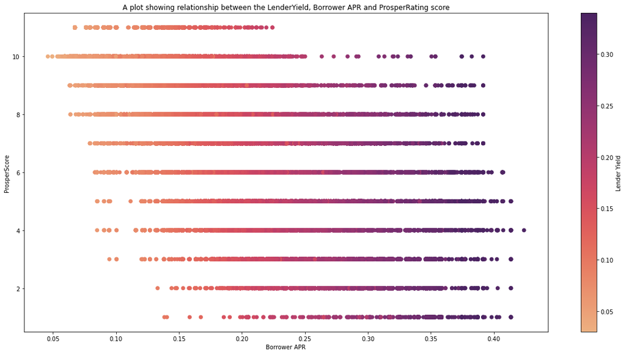

```python
plt.figure(figsize = [20, 10])
plt.scatter(data=loan_data_clean,c='LenderYield',x = 'BorrowerAPR',y='ProsperScore',cmap = 'flare')
plt.colorbar(label = 'Lender Yield')
plt.xlabel('Borrower APR');
plt.ylabel('ProsperScore')
;
plt.title ('A plot showing relationship between the LenderYield, Borrower APR and ProsperRating score');
```

> Clearly the relationship between all the variables of Borrower APR and Lender yield are directly positively correlated as when the interest borrowers pays more , the lender yield will increase. Higher the prosper score lower will lower borrower apr and then the lender yield will also be lower.

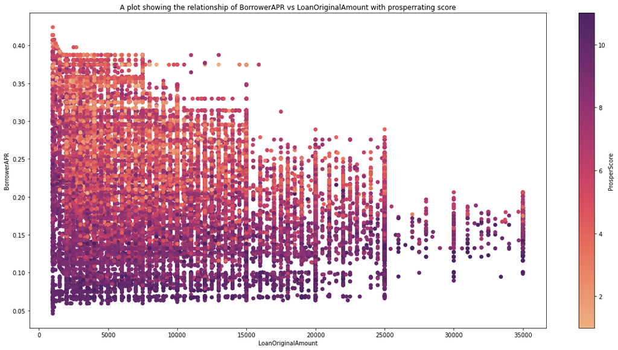

```python
plt.figure(figsize=[20, 10])
plt.scatter(data = loan_data_clean, c = 'ProsperScore', y = 'BorrowerAPR', x='LoanOriginalAmount', cmap='flare')
plt.colorbar(label = 'ProsperScore')
plt.xlabel('LoanOriginalAmount')
plt.ylabel('BorrowerAPR')
plt.title('A plot showing the relationship of BorrowerAPR vs LoanOriginalAmount with prosperrating score');
```

> From the chart, most of the loans with higher amounts (>$20,000) are taken by people with higher prosper score and they have really have low interest rate

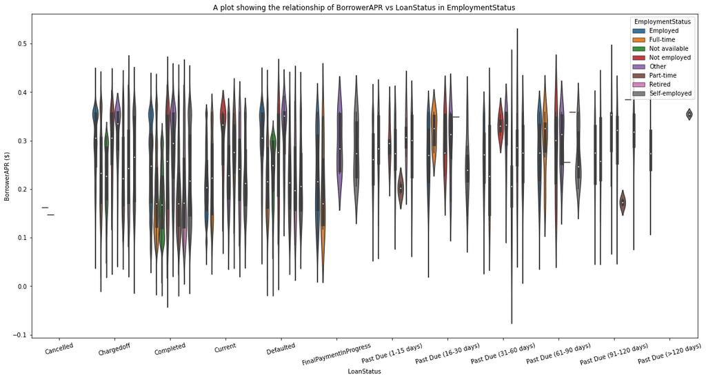

```python
plt.figure(figsize=[20, 10])
sb.violinplot(data = loan_data_clean, x="LoanStatus", y="BorrowerAPR", hue="EmploymentStatus")
sb.light_palette("seagreen", as_cmap=True)
plt.xlabel('LoanStatus')
plt.ylabel('BorrowerAPR ($)')
plt.xticks(rotation=15)
plt.title('A plot showing the relationship of BorrowerAPR vs LoanStatus in EmploymentStatus');
```

### Talk about some of the relationships you observed in this part of the investigation. Were there features that strengthened each other in terms of looking at your feature(s) of interest?

#### Relation between BorrowerAPR, LoanOriginalAmount, Prosperscore

> we tend to have higher prosperscore with low BorrowerAPR interest for larger loanOriginalAmount.

> From Values below $15000, there are high interest rate with low prosperscore. So meaning they charge more on lesser amoint compare to large amount.

### Were there any interesting or surprising interactions between features?

> Scatter plot were also created to find out that ProsperScore and BorrowerAPR were negatively correlated as higher the prosper score the lower will be the risk attached hence lower will be the APR and that further lowers down the lenders yield